# PracMacLrnProject092014

John Ewert

Wednesday, September 17, 2014

## Practical Machine Learning Course Project

### September, 2014

### Goal of Project

The goal of the project is to predict how a certain exercise was performed, using machine learning methods on a supplied Human Activity Recognition dataset.

### Data

The training data for this project are available here:

https://d396qusza40orc.cloudfront.net/predmachlearn/pml-training.csv

The twenty-example test data are available here:

https://d396qusza40orc.cloudfront.net/predmachlearn/pml-testing.csv

The data for this project come from this source: http://groupware.les.inf.puc-rio.br/har.

The data comes from Ugulino, W.; Cardador, D.; Vega, K.; Velloso, E.; Milidiu, R.; Fuks, H. Wearable Computing: Accelerometers’ Data Classification of Body Postures and Movements. Proceedings of 21st Brazilian Symposium on Artificial Intelligence. Advances in Artificial Intelligence - SBIA 2012. In: Lecture Notes in Computer Science. , pp. 52-61. Curitiba, PR: Springer Berlin / Heidelberg, 2012. ISBN 978-3-642-34458-9. DOI: 10.1007/978-3-642-34459-6_6.

Read more: http://groupware.les.inf.puc-rio.br/har#sbia_paper_section#ixzz3DyysIdjA

### Processing of Data

The following code chunk reads the .csv data (testing and training) from the working directory. Data is split 60/20/20 into training/cross-validation/testing sets. I process the data to remove variables unlikely to be predictive of the outcome (“classe”). I looked for variables with near zero variance, variables that contained very little data (approximately 400 entries or fewer out of the 11,000+ observations in my training set), and variables that are highly correlated with other variables. The result is a reduction from 160 variables to 46 variables.

I separately remove the same variables from the twenty-example test set.

```r
# Load Data from active directory
setwd("C:/Users/John/Documents/Coursera/PracMacLrn082014/Project")
require(caret); require(psych); require(kernlab)
pml <- read.csv("pml-training.csv")
# Exclude sparse variables and near zero variance variables
set.seed(310)
inTrain <- createDataPartition(y=pml$classe, p=0.6, list=FALSE)
training <- pml[inTrain,]
testblock <- pml[-inTrain,]
# split remaining data 50/50 into crossvalidation and testing
inCV <- createDataPartition(y=testblock$classe, p=0.5, list=FALSE)
crossVal <- testblock[inCV,]
testing <- testblock[-inCV,]
# run some diagnostics on training data
nearZeroVar(training)
```

```
##  [1]   6  12  13  14  15  16  17  20  23  26  51  52  53  54  55  56  57
## [18]  58  59  69  70  71  72  73  74  81  87  88  89  90  91  92  95  98
## [35] 101 125 126 127 128 129 130 133 134 136 139 143 144 145 146 147 148
## [52] 149 150
```

```r
describe(training)
```

[output not shown]

[output cut: 428 more lines]

[output not shown]

```r
# remove unnecessary features
trimmedTrain <- training[,-nearZeroVar(training)]
descTrimmedTrain<- describe(trimmedTrain)
trimmedTrain <- trimmedTrain[,descTrimmedTrain$vars[descTrimmedTrain$n > 406]]
summary(trimmedTrain)
```

```
##        X            user_name    raw_timestamp_part_1 raw_timestamp_part_2
##  Min.   :    2   adelmo  :2307   Min.   :1.32e+09     Min.   :   301
##  1st Qu.: 4864   carlitos:1872   1st Qu.:1.32e+09     1st Qu.:258622
##  Median : 9788   charles :2140   Median :1.32e+09     Median :496396
##  Mean   : 9807   eurico  :1843   Mean   :1.32e+09     Mean   :501479
##  3rd Qu.:14706   jeremy  :2026   3rd Qu.:1.32e+09     3rd Qu.:752305
##  Max.   :19622   pedro   :1588   Max.   :1.32e+09     Max.   :998750
##
##           cvtd_timestamp   num_window    roll_belt       pitch_belt
##  28/11/2011 14:14: 898   Min.   :  1   Min.   :-28.9   Min.   :-54.90
##  05/12/2011 11:24: 890   1st Qu.:220   1st Qu.:  1.1   1st Qu.:  1.80
##  30/11/2011 17:11: 863   Median :422   Median :113.0   Median :  5.32
##  02/12/2011 14:57: 859   Mean   :430   Mean   : 64.5   Mean   :  0.48
##  05/12/2011 11:25: 857   3rd Qu.:645   3rd Qu.:123.0   3rd Qu.: 15.40
##  05/12/2011 14:23: 851   Max.   :864   Max.   :162.0   Max.   : 60.10
##  (Other)         :6558
##     yaw_belt      total_accel_belt  gyros_belt_x     gyros_belt_y
##  Min.   :-179.0   Min.   : 0.0     Min.   :-0.960   Min.   :-0.6400
##  1st Qu.: -88.3   1st Qu.: 3.0     1st Qu.:-0.050   1st Qu.: 0.0000
##  Median : -12.8   Median :17.0     Median : 0.030   Median : 0.0200
##  Mean   : -11.5   Mean   :11.3     Mean   :-0.006   Mean   : 0.0391
##  3rd Qu.:  12.4   3rd Qu.:18.0     3rd Qu.: 0.110   3rd Qu.: 0.1100
##  Max.   : 179.0   Max.   :29.0     Max.   : 2.200   Max.   : 0.6100
##
##   gyros_belt_z     accel_belt_x      accel_belt_y    accel_belt_z
##  Min.   :-1.460   Min.   :-120.00   Min.   :-54.0   Min.   :-275
##  1st Qu.:-0.200   1st Qu.: -21.00   1st Qu.:  3.0   1st Qu.:-162
##  Median :-0.100   Median : -15.00   Median : 36.0   Median :-152
##  Mean   :-0.134   Mean   :  -5.84   Mean   : 30.3   Mean   : -73
##  3rd Qu.:-0.020   3rd Qu.:  -5.00   3rd Qu.: 61.0   3rd Qu.:  27
##  Max.   : 1.620   Max.   :  81.00   Max.   :164.0   Max.   : 104
##
##  magnet_belt_x   magnet_belt_y magnet_belt_z     roll_arm
##  Min.   :-52.0   Min.   :359   Min.   :-623   Min.   :-180.0
##  1st Qu.:  9.0   1st Qu.:581   1st Qu.:-375   1st Qu.: -31.8
##  Median : 34.0   Median :601   Median :-320   Median :   0.0
##  Mean   : 55.2   Mean   :593   Mean   :-346   Mean   :  17.9
##  3rd Qu.: 59.0   3rd Qu.:610   3rd Qu.:-306   3rd Qu.:  77.4
##  Max.   :481.0   Max.   :673   Max.   : 293   Max.   : 179.0
##
```

[output cut: 65 more lines]

```
##  Min.   :-498.0   Min.   :-595    Min.   :-446.0   Min.   :-1280
##  1st Qu.:-177.0   1st Qu.:  57    1st Qu.:-182.0   1st Qu.: -615
##  Median : -57.0   Median : 201    Median : -40.0   Median : -381
##  Mean   : -60.9   Mean   : 165    Mean   : -55.3   Mean   : -312
##  3rd Qu.:  76.0   3rd Qu.: 314    3rd Qu.:  26.0   3rd Qu.:  -71
##  Max.   : 477.0   Max.   : 923    Max.   : 287.0   Max.   :  672
##
##  magnet_forearm_y magnet_forearm_z classe
##  Min.   :-896     Min.   :-966     A:3348
##  1st Qu.:   7     1st Qu.: 193     B:2279
##  Median : 596     Median : 512     C:2054
##  Mean   : 382     Mean   : 394     D:1930
##  3rd Qu.: 737     3rd Qu.: 652     E:2165
##  Max.   :1480     Max.   :1090
##
```

```r
trimmedTrain <- trimmedTrain[,-c(1,2,3,4,5,6)]
# prepare crossval data and test data
trimmedTest <- testing[,-nearZeroVar(training)]
trimmedTest <- trimmedTest[,descTrimmedTrain$vars[descTrimmedTrain$n > 406]]
trimmedTest <- trimmedTest[,-c(1,2,3,4,5,6)]
trimmedCrossVal <- crossVal[,-nearZeroVar(training)]
trimmedCrossVal <- trimmedCrossVal[,descTrimmedTrain$vars[descTrimmedTrain$n > 406]]
trimmedCrossVal <- trimmedCrossVal[,-c(1,2,3,4,5,6)]
# read and prepare assignment testing data
testTwenty <- read.csv("pml-testing.csv")
trimmedTwenty <- testTwenty[,-nearZeroVar(training)]
trimmedTwenty <- trimmedTwenty[,descTrimmedTrain$vars[descTrimmedTrain$n > 406]]
trimmedTwenty <- trimmedTwenty[,-c(1,2,3,4,5,6,59)]

# find highly correlated features
ncol(trimmedTrain)
```

```
## [1] 53
```

```r
descrCorr <- cor(trimmedTrain[,-ncol(trimmedTrain)])
highCorr <- findCorrelation(descrCorr, 0.90)
trimmedTrain <- trimmedTrain[, -highCorr]
trimmedCrossVal <- trimmedCrossVal[, -highCorr]
trimmedTest <- trimmedTest[, -highCorr]
trimmedTwenty <- trimmedTwenty[, -highCorr]
ncol(trimmedTrain)
```

```
## [1] 46
```

### Model Fitting

```r
require(randomForest)
```

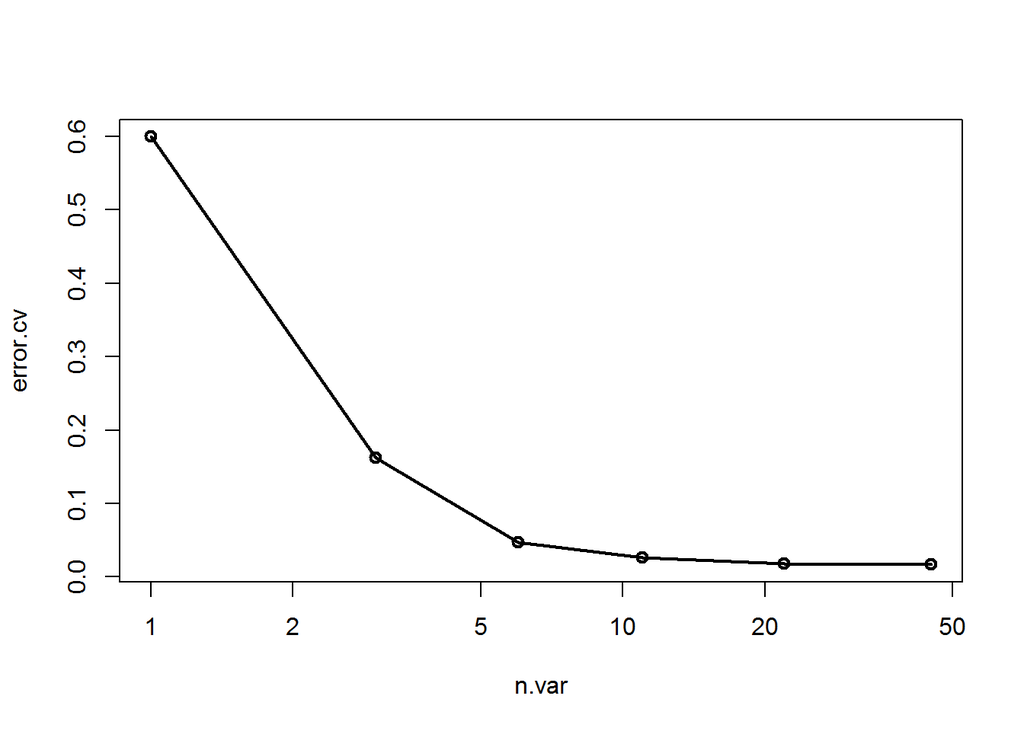

```r
set.seed(7366)
rfFit <- rfcv(trainx = trimmedTrain[,-ncol(trimmedTrain)],
              trainy = trimmedTrain$classe, cv.fold = 10, ntree = 12, keep.forest = TRUE, verbose = TRUE)
with(rfFit, plot(n.var, error.cv, log="x", type="o", lwd=2))
```

```r
rfFit[1]
```

```
## $n.var
## [1] 45 22 11  6  3  1
```

To see if these results hold on my cross-validation set, I fit three Random Forest models on the training set and calculate errors on the cross-validation set. The models use 6, 11, and 22 trees respectively. For the 11-tree model, Out-of-Bag estimate of error rate is 5.13%, and the error rate on the cross-validation set is 1.4%.

```r
set.seed(3840)
rf1 <- randomForest(classe ~ ., trimmedTrain, ntree=6, keep.forest=T,
                    xtest=trimmedCrossVal[,-ncol(trimmedCrossVal)],
                    ytest=trimmedCrossVal[,ncol(trimmedCrossVal)])
rf1
```

```
##
## Call:
##  randomForest(formula = classe ~ ., data = trimmedTrain, ntree = 6,      keep.forest = T, xtest = trimmedCrossVal[, -ncol(trimmedCrossVal)],      ytest = trimmedCrossVal[, ncol(trimmedCrossVal)])
##                Type of random forest: classification
##                      Number of trees: 6
## No. of variables tried at each split: 6
##
##         OOB estimate of  error rate: 8.55%
## Confusion matrix:
##      A    B    C    D    E class.error
## A 2995   74   27   44    8     0.04860
## B   78 1865   79   59   48     0.12400
## C   34   81 1729   55   27     0.10228
## D   42   34   69 1619   31     0.09805
## E   29   46   43   36 1884     0.07556
##                 Test set error rate: 2.22%
## Confusion matrix:
##      A   B   C   D   E class.error
## A 1111   2   0   3   0     0.00448
## B    9 737   9   1   3     0.02899
## C    1   9 667   4   3     0.02485
## D    0   1  20 617   5     0.04044
## E    0   4   3  10 704     0.02358
```

```r
set.seed(3840)
rf2 <- randomForest(classe ~ ., trimmedTrain, ntree=11, keep.forest=T,
                    xtest=trimmedCrossVal[,-ncol(trimmedCrossVal)],
                    ytest=trimmedCrossVal[,ncol(trimmedCrossVal)], importance = TRUE)
rf2
```

```
##
## Call:
##  randomForest(formula = classe ~ ., data = trimmedTrain, ntree = 11,      keep.forest = T, xtest = trimmedCrossVal[, -ncol(trimmedCrossVal)],      ytest = trimmedCrossVal[, ncol(trimmedCrossVal)], importance = TRUE)
##                Type of random forest: classification
##                      Number of trees: 11
## No. of variables tried at each split: 6
##
##         OOB estimate of  error rate: 5.13%
## Confusion matrix:
##      A    B    C    D    E class.error
## A 3256   37   15   14    7     0.02193
## B   73 2081   57   29   28     0.08245
## C   14   66 1912   33   14     0.06229
## D   14   23   57 1815   11     0.05469
## E   16   40   32   20 2043     0.05021
##                 Test set error rate: 1.4%
## Confusion matrix:
##      A   B   C   D   E class.error
## A 1114   1   1   0   0    0.001792
## B   10 745   3   0   1    0.018445
## C    1   8 668   6   1    0.023392
## D    0   0  10 632   1    0.017107
## E    0   2   3   7 709    0.016644
```

```r
set.seed(3840)
rf3 <- randomForest(classe ~ ., trimmedTrain, ntree=22, keep.forest=T,
                    xtest=trimmedCrossVal[,-ncol(trimmedCrossVal)],
                    ytest=trimmedCrossVal[,ncol(trimmedCrossVal)])
rf3
```

```
##
## Call:
##  randomForest(formula = classe ~ ., data = trimmedTrain, ntree = 22,      keep.forest = T, xtest = trimmedCrossVal[, -ncol(trimmedCrossVal)],      ytest = trimmedCrossVal[, ncol(trimmedCrossVal)])
##                Type of random forest: classification
##                      Number of trees: 22
## No. of variables tried at each split: 6
##
##         OOB estimate of  error rate: 2.09%
## Confusion matrix:
##      A    B    C    D    E class.error
## A 3316   17    2    9    4    0.009558
## B   27 2209   32    7    4    0.030715
## C    1   39 1988   20    5    0.031661
## D    4    4   36 1879    7    0.026425
## E    3    8    6   11 2137    0.012933
##                 Test set error rate: 1.07%
## Confusion matrix:
##      A   B   C   D   E class.error
## A 1114   1   0   1   0    0.001792
## B    4 753   2   0   0    0.007905
## C    0   7 673   3   1    0.016082
## D    0   0  14 629   0    0.021773
## E    0   0   0   9 712    0.012483
```

```r
# Select rf2 (11 trees) for model. error.cv seems to become fairly level at 11 trees
set.seed(3840)
rf2 <- randomForest(classe ~ ., trimmedTrain, ntree=11, keep.forest=T,
                    xtest=trimmedTest[,-ncol(trimmedTest)],
                    ytest=trimmedTest[,ncol(trimmedTest)], importance = TRUE)
rf2
```

```
##
## Call:
##  randomForest(formula = classe ~ ., data = trimmedTrain, ntree = 11,      keep.forest = T, xtest = trimmedTest[, -ncol(trimmedTest)],      ytest = trimmedTest[, ncol(trimmedTest)], importance = TRUE)
##                Type of random forest: classification
##                      Number of trees: 11
## No. of variables tried at each split: 6
##
##         OOB estimate of  error rate: 5.08%
## Confusion matrix:
##      A    B    C    D    E class.error
## A 3248   31   10   23   11     0.02257
## B   63 2097   52   30   24     0.07458
## C    7   67 1916   33   17     0.06078
## D   20   27   69 1790   15     0.06819
## E   10   32   29   25 2057     0.04459
##                 Test set error rate: 1.61%
## Confusion matrix:
##      A   B   C   D   E class.error
## A 1112   2   1   1   0    0.003584
## B   10 741   6   1   1    0.023715
## C    0  14 668   2   0    0.023392
## D    1   1  14 626   1    0.026439
## E    0   2   3   3 713    0.011096
```

I expect the CV-data-based error rate and the k-fold cross-validation error rate to be somewhat low estimates of error on out-of-sample data. The out-of-bag estimate should be an unbiased estimate. Thus, I would not be surprised to see one error in my predictions of the twenty-example test.

Now I run the “rf2” model (11 tree Random Forest) on the twenty-example test set to produce “answers” to submit for the project.

```r
# get randomForest predictions on the testTwenty set
answers <- predict(rf2, trimmedTwenty, type="response")
```

All of the answers proved to be correct upon submission.